# Problem Statement

## Background and Context

The policymaker of a tourism company named "Visit with us" wants to enable and establish a viable business model to expand the customer base. One of the ways to expand the customer base is to introduce a new offering of packages. Currently, there are 5 types of packages the company is offering - Basic, Standard, Deluxe, Super Deluxe, and King. Looking at the data of the last year, it was observed that 18% of the customers purchased the packages. However, it was difficult to identify the potential customers because customers were contacted at random without looking at the available information.

The company is now planning to launch a new product i.e. Wellness Tourism Package. Wellness Tourism is a package that allows the traveler to maintain, enhance, or kick-start a healthy lifestyle, and support or increase one's sense of well-being. For the launch of the new package, the company wants to harness the available data of existing and potential customers to target the right customers.

## Objective

You as a Data Scientist at "Visit with us" travel company has to analyze the customer data and information to provide recommendations to the policymaker and build a model to predict the chances of a potential customer purchasing the newly introduced travel package before the customer is contacted.

## Key Questions

1. How can we use different ensemble techniques - Decision Tree, Random Forest, Bagging, Boosting, and Stacking to build a model to correctly predict which of the exsisting and potential customers will purchase Wellness Tourism Package?
2. Which variables are most significant to determine whether an exsisting and potential customer will purchase the Wellness Tourism Package?
3. What business recommendations can we give based on the analysis?

## Customer details:

- `CustomerID`: Unique customer ID
- `ProdTaken`: Whether the customer has purchased a package or not (0: No, 1: Yes)
- `Age`: Age of customer
- `TypeofContact`: How customer was contacted (Company Invited or Self Inquiry)
- `CityTier`: City tier depends on the development of a city, population, facilities, and living standards. The categories are ordered i.e. Tier 1 > Tier 2 > Tier 3
- `Occupation`: Occupation of customer
- `Gender`: Gender of customer
- `NumberOfPersonVisiting`: Total number of persons planning to take the trip with the customer
- `PreferredPropertyStar`: Preferred hotel property rating by customer
- `MaritalStatus`: Marital status of customer
- `NumberOfTrips`: Average number of trips in a year by customer
- `Passport`: The customer has a passport or not (0: No, 1: Yes)
- `OwnCar`: Whether the customers own a car or not (0: No, 1: Yes)
- `NumberOfChildrenVisiting`: Total number of children with age less than 5 planning to take the trip with the customer
- `Designation`: Designation of the customer in the current organization
- `MonthlyIncome`: Gross monthly income of the customer

## Customer interaction data:

- `PitchSatisfactionScore`: Sales pitch satisfaction score
- `ProductPitched`: Product pitched by the salesperson
- `NumberOfFollowups`: Total number of follow-ups has been done by the salesperson after the sales pitch
- `DurationOfPitch`: Duration of the pitch by a salesperson to the customer

```python
from google.colab import drive
drive.mount('/content/drive')
```

# Importing necessary libraries

```python
import warnings
warnings.filterwarnings("ignore")

import numpy as np
import pandas as pd

import seaborn as sns
import matplotlib.pyplot as plt

from sklearn.tree import DecisionTreeRegressor
from sklearn.ensemble import BaggingRegressor,RandomForestRegressor, GradientBoostingRegressor, AdaBoostRegressor, StackingRegressor
from sklearn import metrics
from xgboost import XGBRegressor
from sklearn.model_selection import GridSearchCV, train_test_split
```

## Importing dataset

```python
df = pd.read_excel("/content/drive/MyDrive/Colab_Notebooks/4 - Ensemble Techniques/3 - Project 04/Tourism (1).xlsx")
```

# Overview of the dataset

### View the first and last 10 rows of the dataset

```python
df.head(10)
```

|  | CustomerID | ProdTaken | Age | TypeofContact | CityTier | DurationOfPitch | Occupation | Gender | NumberOfPersonVisiting | NumberOfFollowups | ProductPitched | PreferredPropertyStar | MaritalStatus | NumberOfTrips | Passport | PitchSatisfactionScore | OwnCar | NumberOfChildrenVisiting | Designation | MonthlyIncome |
| --- | --- | --- | --- | --- | --- | --- | --- | --- | --- | --- | --- | --- | --- | --- | --- | --- | --- | --- | --- | --- |
| 0 | 200000 | 1 | 41.0 | Self Enquiry | 3 | 6.0 | Salaried | Female | 3 | 3.0 | Deluxe | 3.0 | Single | 1.0 | 1 | 2 | 1 | 0.0 | Manager | 20993.0 |
| 1 | 200001 | 0 | 49.0 | Company Invited | 1 | 14.0 | Salaried | Male | 3 | 4.0 | Deluxe | 4.0 | Divorced | 2.0 | 0 | 3 | 1 | 2.0 | Manager | 20130.0 |
| 2 | 200002 | 1 | 37.0 | Self Enquiry | 1 | 8.0 | Free Lancer | Male | 3 | 4.0 | Basic | 3.0 | Single | 7.0 | 1 | 3 | 0 | 0.0 | Executive | 17090.0 |
| 3 | 200003 | 0 | 33.0 | Company Invited | 1 | 9.0 | Salaried | Female | 2 | 3.0 | Basic | 3.0 | Divorced | 2.0 | 1 | 5 | 1 | 1.0 | Executive | 17909.0 |
| 4 | 200004 | 0 | NaN | Self Enquiry | 1 | 8.0 | Small Business | Male | 2 | 3.0 | Basic | 4.0 | Divorced | 1.0 | 0 | 5 | 1 | 0.0 | Executive | 18468.0 |
| 5 | 200005 | 0 | 32.0 | Company Invited | 1 | 8.0 | Salaried | Male | 3 | 3.0 | Basic | 3.0 | Single | 1.0 | 0 | 5 | 1 | 1.0 | Executive | 18068.0 |
| 6 | 200006 | 0 | 59.0 | Self Enquiry | 1 | 9.0 | Small Business | Female | 2 | 2.0 | Basic | 5.0 | Divorced | 5.0 | 1 | 2 | 1 | 1.0 | Executive | 17670.0 |
| 7 | 200007 | 0 | 30.0 | Self Enquiry | 1 | 30.0 | Salaried | Male | 3 | 3.0 | Basic | 3.0 | Married | 2.0 | 0 | 2 | 0 | 1.0 | Executive | 17693.0 |
| 8 | 200008 | 0 | 38.0 | Company Invited | 1 | 29.0 | Salaried | Male | 2 | 4.0 | Standard | 3.0 | Unmarried | 1.0 | 0 | 3 | 0 | 0.0 | Senior Manager | 24526.0 |
| 9 | 200009 | 0 | 36.0 | Self Enquiry | 1 | 33.0 | Small Business | Male | 3 | 3.0 | Deluxe | 3.0 | Divorced | 7.0 | 0 | 3 | 1 | 0.0 | Manager | 20237.0 |

```python
df.tail(10)
```

|  | CustomerID | ProdTaken | Age | TypeofContact | CityTier | DurationOfPitch | Occupation | Gender | NumberOfPersonVisiting | NumberOfFollowups | ProductPitched | PreferredPropertyStar | MaritalStatus | NumberOfTrips | Passport | PitchSatisfactionScore | OwnCar | NumberOfChildrenVisiting | Designation | MonthlyIncome |
| --- | --- | --- | --- | --- | --- | --- | --- | --- | --- | --- | --- | --- | --- | --- | --- | --- | --- | --- | --- | --- |
| 4878 | 204878 | 1 | 35.0 | Self Enquiry | 1 | 17.0 | Small Business | Male | 3 | 4.0 | Deluxe | 5.0 | Unmarried | 3.0 | 0 | 4 | 0 | 1.0 | Manager | 24803.0 |
| 4879 | 204879 | 1 | 26.0 | Self Enquiry | 2 | 27.0 | Small Business | Female | 4 | 4.0 | Basic | 4.0 | Married | 2.0 | 1 | 3 | 0 | 2.0 | Executive | 22347.0 |
| 4880 | 204880 | 1 | 59.0 | Self Enquiry | 1 | 28.0 | Small Business | Female | 4 | 4.0 | Deluxe | 4.0 | Married | 6.0 | 0 | 3 | 1 | 2.0 | Manager | 28686.0 |
| 4881 | 204881 | 1 | 41.0 | Self Enquiry | 2 | 25.0 | Salaried | Male | 3 | 2.0 | Basic | 5.0 | Married | 2.0 | 0 | 1 | 1 | 2.0 | Executive | 21065.0 |
| 4882 | 204882 | 1 | 37.0 | Self Enquiry | 2 | 20.0 | Salaried | Male | 3 | 5.0 | Basic | 5.0 | Married | 6.0 | 1 | 5 | 1 | 2.0 | Executive | 23317.0 |
| 4883 | 204883 | 1 | 49.0 | Self Enquiry | 3 | 9.0 | Small Business | Male | 3 | 5.0 | Deluxe | 4.0 | Unmarried | 2.0 | 1 | 1 | 1 | 1.0 | Manager | 26576.0 |
| 4884 | 204884 | 1 | 28.0 | Company Invited | 1 | 31.0 | Salaried | Male | 4 | 5.0 | Basic | 3.0 | Single | 3.0 | 1 | 3 | 1 | 2.0 | Executive | 21212.0 |
| 4885 | 204885 | 1 | 52.0 | Self Enquiry | 3 | 17.0 | Salaried | Female | 4 | 4.0 | Standard | 4.0 | Married | 7.0 | 0 | 1 | 1 | 3.0 | Senior Manager | 31820.0 |
| 4886 | 204886 | 1 | 19.0 | Self Enquiry | 3 | 16.0 | Small Business | Male | 3 | 4.0 | Basic | 3.0 | Single | 3.0 | 0 | 5 | 0 | 2.0 | Executive | 20289.0 |
| 4887 | 204887 | 1 | 36.0 | Self Enquiry | 1 | 14.0 | Salaried | Male | 4 | 4.0 | Basic | 4.0 | Unmarried | 3.0 | 1 | 3 | 1 | 2.0 | Executive | 24041.0 |

## Checking the shape of the Dataset

```python
print(f"There are {df.shape[0]} rows and {df.shape[1]} columns.")  # f-string
```

```
There are 4888 rows and 20 columns.
```

### Check data types and number of non-null values for each column

```python
df.info()
```

```
<class 'pandas.core.frame.DataFrame'>
RangeIndex: 4888 entries, 0 to 4887
Data columns (total 20 columns):
 #   Column                    Non-Null Count  Dtype
---  ------                    --------------  -----
 0   CustomerID                4888 non-null   int64
 1   ProdTaken                 4888 non-null   int64
 2   Age                       4662 non-null   float64
 3   TypeofContact             4863 non-null   object
 4   CityTier                  4888 non-null   int64
 5   DurationOfPitch           4637 non-null   float64
 6   Occupation                4888 non-null   object
 7   Gender                    4888 non-null   object
 8   NumberOfPersonVisiting    4888 non-null   int64
 9   NumberOfFollowups         4843 non-null   float64
 10  ProductPitched            4888 non-null   object
 11  PreferredPropertyStar     4862 non-null   float64
 12  MaritalStatus             4888 non-null   object
 13  NumberOfTrips             4748 non-null   float64
 14  Passport                  4888 non-null   int64
 15  PitchSatisfactionScore    4888 non-null   int64
 16  OwnCar                    4888 non-null   int64
 17  NumberOfChildrenVisiting  4822 non-null   float64
 18  Designation               4888 non-null   object
 19  MonthlyIncome             4655 non-null   float64
dtypes: float64(7), int64(7), object(6)
memory usage: 763.9+ KB
```

## Observations:

- We can see that there are total of 20 columns and 4,888 rows in the dataset.
- All columns' data type is either integer or float or object.
- There are a number of non-null values in some column. We can further confirm this using `isna()` method.

```python
df.isna().sum()
```

```
CustomerID                    0
ProdTaken                     0
Age                         226
TypeofContact                25
CityTier                      0
DurationOfPitch             251
Occupation                    0
Gender                        0
NumberOfPersonVisiting        0
NumberOfFollowups            45
ProductPitched                0
PreferredPropertyStar        26
MaritalStatus                 0
NumberOfTrips               140
Passport                      0
PitchSatisfactionScore        0
OwnCar                        0
NumberOfChildrenVisiting     66
Designation                   0
MonthlyIncome               233
dtype: int64
```

## Observations

- 8 columns have missing values with `DurationOfPitch` with the most missing values at 251.
- Since all the missing values are about 5% or less of all dataset information, they will be dropped. Dropping the missing values is not expected to have a significant impact on the results.

## Dropping Missing Values

```python
df.dropna(inplace=True)
```

## Let's re-check number of non-null values in the dataset

```python
df.isna().sum()
```

```
CustomerID                  0
ProdTaken                   0
Age                         0
TypeofContact               0
CityTier                    0
DurationOfPitch             0
Occupation                  0
Gender                      0
NumberOfPersonVisiting      0
NumberOfFollowups           0
ProductPitched              0
PreferredPropertyStar       0
MaritalStatus               0
NumberOfTrips               0
Passport                    0
PitchSatisfactionScore      0
OwnCar                      0
NumberOfChildrenVisiting    0
Designation                 0
MonthlyIncome               0
dtype: int64
```

## Observation

- All missing values have been dropped.

## Checking for duplicate entries in the Dataset

```python
df.duplicated().sum()
```

```
0
```

## Observation

There are no duplicate entries in the dataset.

```python
df.nunique()
```

```
CustomerID                  4128
ProdTaken                      2
Age                           44
TypeofContact                  2
CityTier                       3
DurationOfPitch               33
Occupation                     4
Gender                         3
NumberOfPersonVisiting         5
NumberOfFollowups              6
ProductPitched                 5
PreferredPropertyStar          3
MaritalStatus                  4
NumberOfTrips                 12
Passport                       2
PitchSatisfactionScore         5
OwnCar                         2
NumberOfChildrenVisiting       4
Designation                    5
MonthlyIncome               2182
dtype: int64
```

- At this point, let's drop 'CustomerID' column as it is an ID variable and will not add value to the model.

```python
#Dropping customer ID column from the dataframe
df.drop(['CustomerID'],axis=1,inplace=True)
```

## Lets convert the columns with an 'object' datatype into categorical variables

```python
for feature in df.columns: # Loop through all columns in the dataframe
    if df[feature].dtype == 'object': # Only apply for columns with categorical strings
        df[feature] = pd.Categorical(df[feature])# Replace strings with an integer
df.info()
```

```
<class 'pandas.core.frame.DataFrame'>
Int64Index: 4128 entries, 0 to 4887
Data columns (total 19 columns):
 #   Column                    Non-Null Count  Dtype
---  ------                    --------------  -----
 0   ProdTaken                 4128 non-null   int64
 1   Age                       4128 non-null   float64
 2   TypeofContact             4128 non-null   category
 3   CityTier                  4128 non-null   int64
 4   DurationOfPitch           4128 non-null   float64
 5   Occupation                4128 non-null   category
 6   Gender                    4128 non-null   category
 7   NumberOfPersonVisiting    4128 non-null   int64
 8   NumberOfFollowups         4128 non-null   float64
 9   ProductPitched            4128 non-null   category
 10  PreferredPropertyStar     4128 non-null   float64
 11  MaritalStatus             4128 non-null   category
 12  NumberOfTrips             4128 non-null   float64
 13  Passport                  4128 non-null   int64
 14  PitchSatisfactionScore    4128 non-null   int64
 15  OwnCar                    4128 non-null   int64
 16  NumberOfChildrenVisiting  4128 non-null   float64
 17  Designation               4128 non-null   category
 18  MonthlyIncome             4128 non-null   float64
dtypes: category(6), float64(7), int64(6)
memory usage: 476.8 KB
```

## Observation

- Columns with the object type have been converted to Categorical.
- All columns are either int, float or categorical.

## Checking the statistical summary of the Dataset

```python
df.describe().T
```

|  | count | mean | std | min | 25% | 50% | 75% | max |
| --- | --- | --- | --- | --- | --- | --- | --- | --- |
| ProdTaken | 4128.0 | 0.193072 | 0.394757 | 0.0 | 0.0 | 0.0 | 0.0 | 1.0 |
| Age | 4128.0 | 37.231831 | 9.174521 | 18.0 | 31.0 | 36.0 | 43.0 | 61.0 |
| CityTier | 4128.0 | 1.663275 | 0.920640 | 1.0 | 1.0 | 1.0 | 3.0 | 3.0 |
| DurationOfPitch | 4128.0 | 15.584787 | 8.398142 | 5.0 | 9.0 | 14.0 | 20.0 | 127.0 |
| NumberOfPersonVisiting | 4128.0 | 2.949370 | 0.718818 | 1.0 | 2.0 | 3.0 | 3.0 | 5.0 |
| NumberOfFollowups | 4128.0 | 3.741521 | 1.006786 | 1.0 | 3.0 | 4.0 | 4.0 | 6.0 |
| PreferredPropertyStar | 4128.0 | 3.578488 | 0.795031 | 3.0 | 3.0 | 3.0 | 4.0 | 5.0 |
| NumberOfTrips | 4128.0 | 3.295300 | 1.856300 | 1.0 | 2.0 | 3.0 | 4.0 | 22.0 |
| Passport | 4128.0 | 0.295300 | 0.456233 | 0.0 | 0.0 | 0.0 | 1.0 | 1.0 |
| PitchSatisfactionScore | 4128.0 | 3.060804 | 1.363064 | 1.0 | 2.0 | 3.0 | 4.0 | 5.0 |
| OwnCar | 4128.0 | 0.612161 | 0.487317 | 0.0 | 0.0 | 1.0 | 1.0 | 1.0 |
| NumberOfChildrenVisiting | 4128.0 | 1.223595 | 0.852685 | 0.0 | 1.0 | 1.0 | 2.0 | 3.0 |
| MonthlyIncome | 4128.0 | 23178.464147 | 4506.614622 | 1000.0 | 20751.0 | 22418.0 | 25301.0 | 98678.0 |

# Observation

`ProdTaken` vs `Passport`

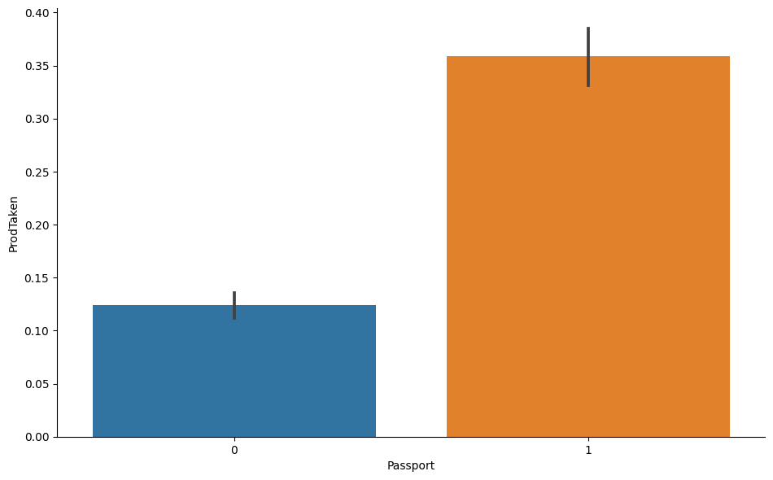

```python
sns.catplot(x="Passport", y="ProdTaken", data=df, kind='bar', height=6, aspect=1.6, estimator=np.mean);
```

- Most of the customers that bought `ProdTaken` have `Passport`.

`Age` vs `MonthlyIncome`

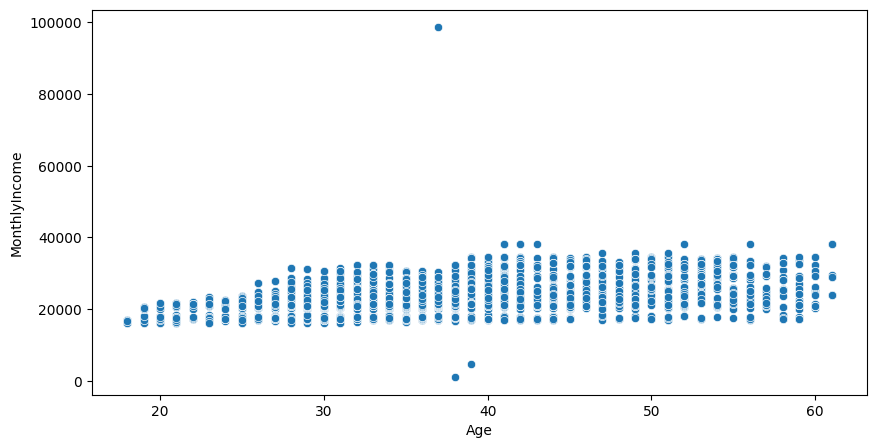

```python
plt.figure(figsize=(10,5))
sns.scatterplot(data=df,x='Age',y='MonthlyIncome')
plt.show()
```

- There is positive correlation between `MonthlyIncome` and `Age`.

`Age` vs `NumberOfTrips`

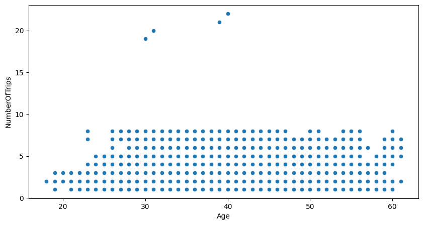

```python
plt.figure(figsize=(10,5))
sns.scatterplot(data=df,x='Age',y='NumberOfTrips')
plt.show()
```

- `Age` and `NumberOfTrips` have somewhat of a positive correlation.

`NumberOfPersonVisiting` vs `NumberOfChildrenVisiting`

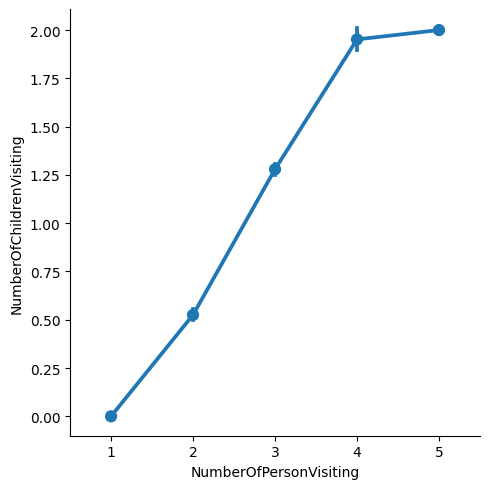

```python
sns.catplot(data=df, x='NumberOfPersonVisiting', y='NumberOfChildrenVisiting', kind='point');
```

- Just as expected 'NumberOfPersonVisiting' is positively correlated with 'NumberOfChildrenVisiting'.

`NumberOfPersonVisiting` vs `NumberOfTrips`

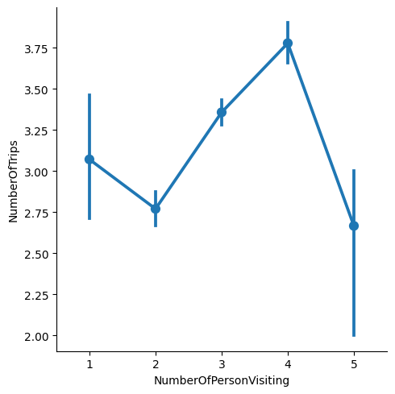

```python
sns.catplot(data=df, x='NumberOfPersonVisiting', y='NumberOfTrips', kind='point');
```

`NumberOfPersonVisiting` vs `MonthlyIncome`

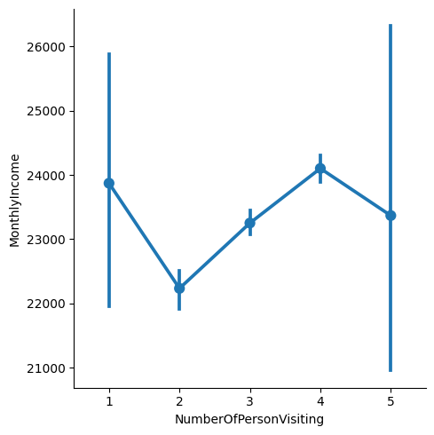

```python
sns.catplot(data=df, x='NumberOfPersonVisiting', y='MonthlyIncome', kind='point');
```

`NumberOfPersonVisiting` vs `NumberOfFollowups`

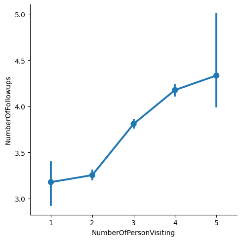

```python
sns.catplot(data=df, x='NumberOfPersonVisiting', y='NumberOfFollowups', kind='point');
```

`NumberOfPersonVisiting` vs. `NumberOfFollowups`

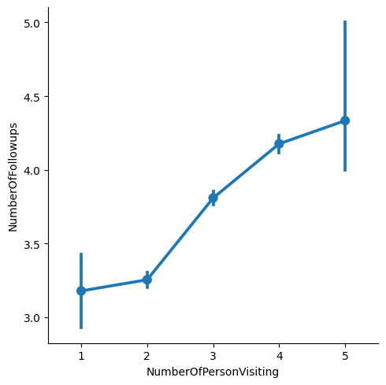

```python
sns.catplot(data=df, x='NumberOfPersonVisiting', y='NumberOfFollowups', kind='point');
```

`NumberOfChildrenVisiting` vs `NumberOfFollowups`

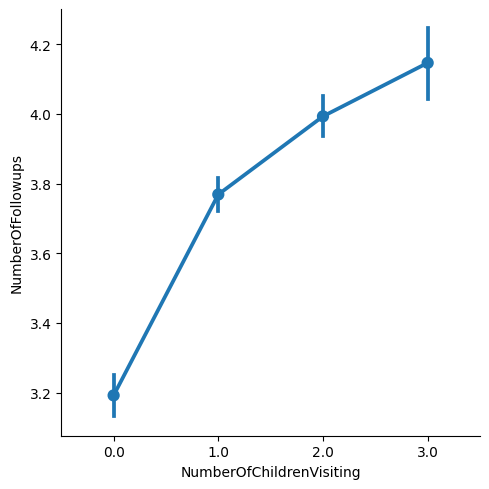

```python
sns.catplot(data=df, x='NumberOfChildrenVisiting', y='NumberOfFollowups', kind='point');
```

`MontlyIncome` vs `NumberOfFollowups`

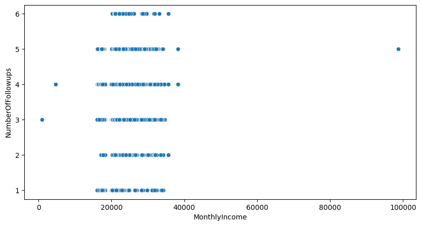

```python
plt.figure(figsize=(10,5))
sns.scatterplot(data=df,x='MonthlyIncome', y='NumberOfFollowups')
plt.show()
```

## Outlier detection and treatment

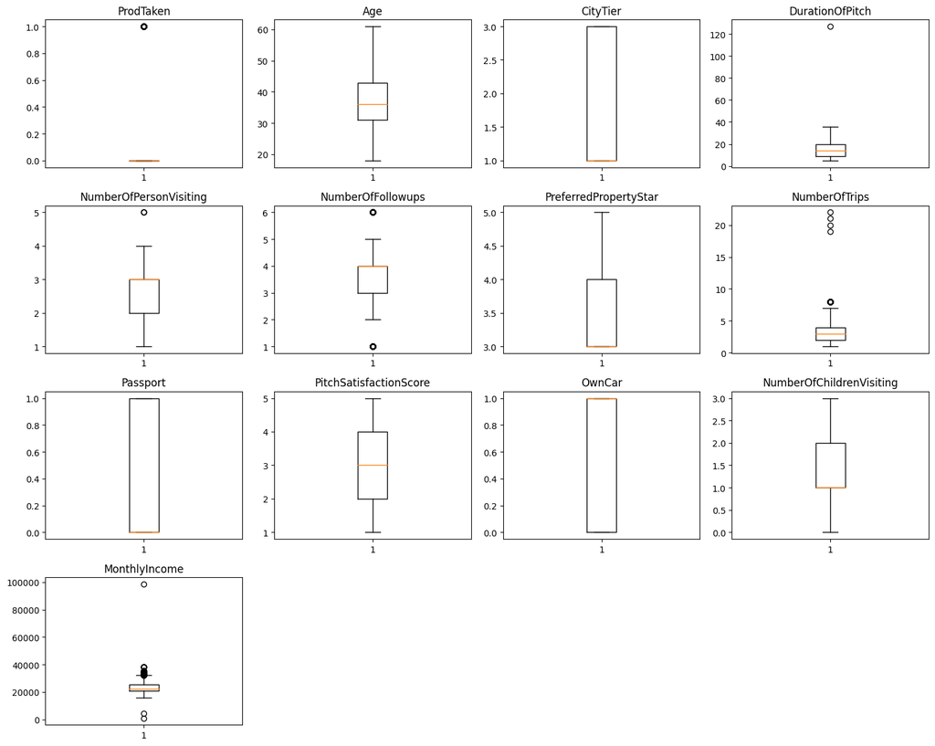

```python
# outlier detection using boxplot
# selecting the numerical columns of data and adding their names in a list
numeric_columns = ['ProdTaken', 'Age', 'CityTier', 'DurationOfPitch', 'NumberOfPersonVisiting', 'NumberOfFollowups','PreferredPropertyStar',
                   'NumberOfTrips', 'Passport', 'PitchSatisfactionScore', 'OwnCar', 'NumberOfChildrenVisiting', 'MonthlyIncome']
plt.figure(figsize=(15, 12))

for i, variable in enumerate(numeric_columns):
    plt.subplot(4, 4, i + 1)
    plt.boxplot(df[variable], whis=1.5)
    plt.tight_layout()
    plt.title(variable)

plt.show()
```

- `DurationOfPitch`, `NumberOfTrips`, and `MonthlyIncome` have obvious outliers.

## Let's check how many outliers are in the above columns

```python
# Calculate the interquartile range (IQR)
Q1 = df['DurationOfPitch'].quantile(0.25)
Q3 = df['DurationOfPitch'].quantile(0.75)
IQR = Q3 - Q1

# Identify outliers using the IQR method
outliers = df[(df['DurationOfPitch'] < (Q1 - 1.5 * IQR)) | (df['DurationOfPitch'] > (Q3 + 1.5 * IQR))]

# Count the number of outliers
num_outliers = len(outliers)

# Print the number of outliers
print("Number of outliers in 'DurationOfPitch':", num_outliers)
```

```
Number of outliers in 'DurationOfPitch': 1
```

```python
# Calculate the interquartile range (IQR)
Q1 = df['NumberOfTrips'].quantile(0.25)
Q3 = df['NumberOfTrips'].quantile(0.75)
IQR = Q3 - Q1

# Identify outliers using the IQR method
outliers = df[(df['NumberOfTrips'] < (Q1 - 1.5 * IQR)) | (df['NumberOfTrips'] > (Q3 + 1.5 * IQR))]

# Count the number of outliers
num_outliers = len(outliers)

# Print the number of outliers
print("Number of outliers in 'NumberOfTrips':", num_outliers)
```

```
Number of outliers in 'NumberOfTrips': 107
```

```python
# Calculate the interquartile range (IQR)
Q1 = df['MonthlyIncome'].quantile(0.25)
Q3 = df['MonthlyIncome'].quantile(0.75)
IQR = Q3 - Q1

# Identify outliers using the IQR method
outliers = df[(df['MonthlyIncome'] < (Q1 - 1.5 * IQR)) | (df['MonthlyIncome'] > (Q3 + 1.5 * IQR))]

# Count the number of outliers
num_outliers = len(outliers)

# Print the number of outliers
print("Number of outliers in 'MonthlyIncome':", num_outliers)
```

```
Number of outliers in 'MonthlyIncome': 223
```

- Outliers in `DurationOfPitch`, `NumberOfTrips`, and `MonthlyIncome`columns will not be treated because we have no way of verifying if these are true outliers or not. Furthermore, all the outliers combined is less than 10% of the data and may not significantly affect the overal dataset.

```python
print(df.ProdTaken.value_counts())
print(df.Age.value_counts())
print(df.TypeofContact.value_counts())
print(df.CityTier.value_counts())
print(df.DurationOfPitch.value_counts())
print(df.Occupation.value_counts())
print(df.Gender.value_counts())
print(df.NumberOfPersonVisiting.value_counts())
print(df.NumberOfFollowups.value_counts())
print(df.ProductPitched.value_counts())
print(df.PreferredPropertyStar.value_counts())
print(df.MaritalStatus.value_counts())
print(df.NumberOfTrips.value_counts())
print(df.Passport.value_counts())
print(df.PitchSatisfactionScore.value_counts())
print(df.OwnCar.value_counts())
print(df.NumberOfChildrenVisiting.value_counts())
print(df.Designation.value_counts())
print(df.MonthlyIncome.value_counts())
```

```
0    3331
1     797
Name: ProdTaken, dtype: int64
36.0    215
35.0    214
30.0    188
31.0    188
34.0    187
33.0    178
37.0    177
32.0    177
38.0    171
29.0    164
39.0    145
41.0    137
28.0    135
27.0    125
40.0    124
42.0    118
43.0    107
46.0    104
45.0     96
26.0     91
44.0     89
50.0     74
47.0     63
25.0     63
51.0     60
49.0     57
48.0     55
52.0     55
55.0     52
53.0     52
54.0     51
24.0     46
23.0     46
22.0     42
59.0     40
21.0     39
20.0     36
```

[output cut: 119 more lines]

```
AVP                250
VP                 104
Name: Designation, dtype: int64
20855.0    7
21020.0    7
21288.0    7
17342.0    7
25482.0    6
          ..
17430.0    1
22441.0    1
17296.0    1
31437.0    1
35558.0    1
Name: MonthlyIncome, Length: 2182, dtype: int64
```

```python
replaceStruct = {
                "Age":     {"< 18-24": 1, "25-34": 2 ,"35-44": 3 ,"45-54": 4, "55-64": 5, "> 65": 6},
                "DurationOfPitch": {"0-5": 1, "6-10":2 , "11-15": 3, "16-20": 4, "21-25": 5, "26-30": 6, "31-35": 7, "36-40": 8, "> 40": 9},
                 "MonthlyIncome": {"1000-10000": 1, "10001 - 20000":2 , "20001 - 30000": 3, "30001 - 40000": 4,"40001 - 50000": 5, "50001 - 60000": 6, "> 60000": 7},
                 "TypeofContact":     {"Self Enquiry": 1, "Company Invited": 2},
                "Occupation":     {"Free Lancer": 1, "Salaried": 2, "Small Business": 3, "Large Business": 4},
                "Gender":     {"Male": 1, "Female": 2, "Fe Male": 2},
                "ProductPitched":     {"Basic": 1, "Deluxe": 2, "Standard": 3, "Super Deluxe": 4, "King": 5},
                "MaritalStatus":      {"Single": 1, "Unmarried": 2, "Divorced": 3, "Married": 4},
                "Designation":     {"Executive": 1, "Manager": 2, "Senior Manager": 3, "AVP": 4, "vp": 5},

                    }
oneHotCols=["TypeofContact","Occupation", "Gender", "ProductPitched", "MaritalStatus", "Designation"]
```

```python
df=df.replace(replaceStruct)
df=pd.get_dummies(df, columns=oneHotCols)
df.head(10)
```

|  | ProdTaken | Age | CityTier | DurationOfPitch | NumberOfPersonVisiting | NumberOfFollowups | PreferredPropertyStar | NumberOfTrips | Passport | PitchSatisfactionScore | ... | ProductPitched_4 | MaritalStatus_3 | MaritalStatus_4 | MaritalStatus_1 | MaritalStatus_2 | Designation_4 | Designation_1 | Designation_2 | Designation_3 | Designation_VP |
| --- | --- | --- | --- | --- | --- | --- | --- | --- | --- | --- | --- | --- | --- | --- | --- | --- | --- | --- | --- | --- | --- |
| 0 | 1 | 41.0 | 3 | 6.0 | 3 | 3.0 | 3.0 | 1.0 | 1 | 2 | ... | 0 | 0 | 0 | 1 | 0 | 0 | 0 | 1 | 0 | 0 |
| 1 | 0 | 49.0 | 1 | 14.0 | 3 | 4.0 | 4.0 | 2.0 | 0 | 3 | ... | 0 | 1 | 0 | 0 | 0 | 0 | 0 | 1 | 0 | 0 |
| 2 | 1 | 37.0 | 1 | 8.0 | 3 | 4.0 | 3.0 | 7.0 | 1 | 3 | ... | 0 | 0 | 0 | 1 | 0 | 0 | 1 | 0 | 0 | 0 |
| 3 | 0 | 33.0 | 1 | 9.0 | 2 | 3.0 | 3.0 | 2.0 | 1 | 5 | ... | 0 | 1 | 0 | 0 | 0 | 0 | 1 | 0 | 0 | 0 |
| 5 | 0 | 32.0 | 1 | 8.0 | 3 | 3.0 | 3.0 | 1.0 | 0 | 5 | ... | 0 | 0 | 0 | 1 | 0 | 0 | 1 | 0 | 0 | 0 |
| 6 | 0 | 59.0 | 1 | 9.0 | 2 | 2.0 | 5.0 | 5.0 | 1 | 2 | ... | 0 | 1 | 0 | 0 | 0 | 0 | 1 | 0 | 0 | 0 |
| 7 | 0 | 30.0 | 1 | 30.0 | 3 | 3.0 | 3.0 | 2.0 | 0 | 2 | ... | 0 | 0 | 1 | 0 | 0 | 0 | 1 | 0 | 0 | 0 |
| 8 | 0 | 38.0 | 1 | 29.0 | 2 | 4.0 | 3.0 | 1.0 | 0 | 3 | ... | 0 | 0 | 0 | 0 | 1 | 0 | 0 | 0 | 1 | 0 |
| 9 | 0 | 36.0 | 1 | 33.0 | 3 | 3.0 | 3.0 | 7.0 | 0 | 3 | ... | 0 | 1 | 0 | 0 | 0 | 0 | 0 | 1 | 0 | 0 |
| 10 | 0 | 35.0 | 1 | 22.0 | 2 | 2.0 | 4.0 | 1.0 | 0 | 3 | ... | 0 | 1 | 0 | 0 | 0 | 0 | 1 | 0 | 0 | 0 |

10 rows × 35 columns

```python
#Let's recheck data info
df.info()
```

```
<class 'pandas.core.frame.DataFrame'>
Int64Index: 4128 entries, 0 to 4887
Data columns (total 35 columns):
 #   Column                    Non-Null Count  Dtype
---  ------                    --------------  -----
 0   ProdTaken                 4128 non-null   int64
 1   Age                       4128 non-null   float64
 2   CityTier                  4128 non-null   int64
 3   DurationOfPitch           4128 non-null   float64
 4   NumberOfPersonVisiting    4128 non-null   int64
 5   NumberOfFollowups         4128 non-null   float64
 6   PreferredPropertyStar     4128 non-null   float64
 7   NumberOfTrips             4128 non-null   float64
 8   Passport                  4128 non-null   int64
 9   PitchSatisfactionScore    4128 non-null   int64
```

[output cut: 27 more lines]

- There are no more categorical columns in the dataset.

```python
df.isnull().sum()
```

```
ProdTaken                   0
Age                         0
CityTier                    0
DurationOfPitch             0
NumberOfPersonVisiting      0
NumberOfFollowups           0
PreferredPropertyStar       0
NumberOfTrips               0
Passport                    0
PitchSatisfactionScore      0
OwnCar                      0
NumberOfChildrenVisiting    0
MonthlyIncome               0
TypeofContact_2             0
TypeofContact_1             0
Occupation_1                0
Occupation_4                0
Occupation_2                0
Occupation_3                0
Gender_2                    0
Gender_1                    0
ProductPitched_1            0
ProductPitched_2            0
ProductPitched_5            0
ProductPitched_3            0
ProductPitched_4            0
MaritalStatus_3             0
MaritalStatus_4             0
MaritalStatus_1             0
MaritalStatus_2             0
Designation_4               0
Designation_1               0
Designation_2               0
Designation_3               0
Designation_VP              0
dtype: int64
```

### Data Preparation for model building

```python
# Separating features and the target column
X = df.drop('ProdTaken', axis=1)
y = df.pop("ProdTaken")
```

```python
# Splitting the data into train and test sets in 70:30 ratio
X_train, X_test, y_train, y_test = train_test_split(X, y, test_size=0.30, random_state=1, stratify=y)
```

```python
X_train.shape, X_test.shape
```

```
((2889, 34), (1239, 34))
```

## Model evaluation criterion

### The model can make wrong predictions as:

1. Predicting a customer doesn't have want to purchase the wellness package but the customer actually wants to.
2. Predicting a customer wants to purchase the wellness pacakge but the customer doesn't.

### Which case is more important?

- Predicting a customer doesn't have want to purchase the wellness package but the customer actually wants to because that may lead to potential revenue loss.

### Which metric to optimize?

- We'll use GridSearchCv for hyperparameter tuning and `r_2 score` to optimize the model.
- R-square - `Coefficient of determination` is used to evaluate the performance of a regression model. It is the amount of the variation in the output dependent attribute which is predictable from the input independent variables.

```python
# function to compute adjusted R-squared
def adj_r2_score(predictors, targets, predictions):
    r2 = r2_score(targets, predictions)
    n = predictors.shape[0]
    k = predictors.shape[1]
    return 1 - ((1 - r2) * (n - 1) / (n - k - 1))


# function to compute MAPE
def mape_score(targets, predictions):
    return np.mean(np.abs(targets - predictions) / targets) * 100


# function to compute different metrics to check performance of a regression model
def model_performance_regression(model, predictors, target):
    """
    Function to compute different metrics to check regression model performance

    model: regressor
    predictors: independent variables
    target: dependent variable
    """

    # predicting using the independent variables
    pred = model.predict(predictors)

    r2 = r2_score(target, pred)  # to compute R-squared
    adjr2 = adj_r2_score(predictors, target, pred)  # to compute adjusted R-squared
    rmse = np.sqrt(mean_squared_error(target, pred))  # to compute RMSE
    mae = mean_absolute_error(target, pred)  # to compute MAE
    mape = mape_score(target, pred)  # to compute MAPE

    # creating a dataframe of metrics
    df_perf = pd.DataFrame(
        {
            "RMSE": rmse,
            "MAE": mae,
            "R-squared": r2,
            "Adj. R-squared": adjr2,
            "MAPE": mape,
        },
        index=[0],
    )

    return df_perf
```

```python
##  Function to calculate r2_score and RMSE on train and test data
def get_model_score(model, flag=True):
    '''
    model : classifier to predict values of X

    '''
    # defining an empty list to store train and test results
    score_list=[]

    pred_train = model.predict(X_train)
    pred_test = model.predict(X_test)

    train_r2=metrics.r2_score(y_train,pred_train)
    test_r2=metrics.r2_score(y_test,pred_test)
    train_rmse=np.sqrt(metrics.mean_squared_error(y_train,pred_train))
    test_rmse=np.sqrt(metrics.mean_squared_error(y_test,pred_test))

    #Adding all scores in the list
    score_list.extend((train_r2,test_r2,train_rmse,test_rmse))

    # If the flag is set to True then only the following print statements will be dispayed, the default value is True
    if flag==True:
        print("R-sqaure on training set : ",metrics.r2_score(y_train,pred_train))
        print("R-square on test set : ",metrics.r2_score(y_test,pred_test))
        print("RMSE on training set : ",np.sqrt(metrics.mean_squared_error(y_train,pred_train)))
        print("RMSE on test set : ",np.sqrt(metrics.mean_squared_error(y_test,pred_test)))

    # returning the list with train and test scores
    return score_list
```

## Decision Tree

```python
dtree=DecisionTreeRegressor(random_state=1)
dtree.fit(X_train,y_train)
```

```
DecisionTreeRegressor(random_state=1)
```

```python
from sklearn.metrics import r2_score, mean_squared_error, mean_absolute_error
```

```python
dtree_model_train_perf=model_performance_regression(dtree, X_train,y_train)
print("Training performance \n",dtree_model_train_perf)
```

```
Training performance
    RMSE  MAE  R-squared  Adj. R-squared  MAPE
0   0.0  0.0        1.0             1.0   0.0
```

```python
dtree_model_test_perf=model_performance_regression(dtree, X_test,y_test)
print("Testing performance \n",dtree_model_test_perf)
```

```
Testing performance
        RMSE       MAE  R-squared  Adj. R-squared  MAPE
0  0.337345  0.113801   0.269042          0.2484   inf
```

- The Decision tree model with default parameters is overfitting the train data.
- Let's see if we can reduce overfitting and improve performance on test data by tuning hyperparameters.

### Hyperparameter Tuning

```python
# Choose the type of classifier.
dtree_tuned = DecisionTreeRegressor(random_state=1)

# Grid of parameters to choose from
parameters = {'max_depth': list(np.arange(2,20)) + [None],
              'min_samples_leaf': [1, 3, 5, 7, 10],
              'max_leaf_nodes' : [2, 3, 5, 10, 15] + [None],
              'min_impurity_decrease': [0.001, 0.01, 0.1, 0.0]
             }

# Type of scoring used to compare parameter combinations
scorer = metrics.make_scorer(metrics.r2_score)

# Run the grid search
grid_obj = GridSearchCV(dtree_tuned, parameters, scoring=scorer,cv=5)
grid_obj = grid_obj.fit(X_train, y_train)

# Set the clf to the best combination of parameters
dtree_tuned = grid_obj.best_estimator_

# Fit the best algorithm to the data.
dtree_tuned.fit(X_train, y_train)
```

```
DecisionTreeRegressor(max_depth=6, min_samples_leaf=3, random_state=1)
```

```python
dtree_tuned_model_train_perf = model_performance_regression(dtree_tuned, X_train,y_train)
print("Training performance \n",dtree_tuned_model_train_perf)
```

```
Training performance
        RMSE       MAE  R-squared  Adj. R-squared  MAPE
0  0.303762  0.184543   0.407912        0.400859   inf
```

```python
dtree_tuned_model_test_perf = model_performance_regression(dtree_tuned, X_test,y_test)
print("Testing performance \n",dtree_tuned_model_test_perf)
```

```
Testing performance
        RMSE       MAE  R-squared  Adj. R-squared  MAPE
0  0.356887  0.221798   0.181902          0.1588   inf
```

**Plotting the feature importance of each variable**

```python
# importance of features in the tree building ( The importance of a feature is computed as the
#(normalized) total reduction of the criterion brought by that feature. It is also known as the Gini importance )

print(pd.DataFrame(dtree_tuned.feature_importances_, columns = ["Imp"], index = X_train.columns).sort_values(by = 'Imp', ascending = False))
```

```
                               Imp
Passport                  0.184443
Designation_1             0.166870
Age                       0.152721
DurationOfPitch           0.139375
CityTier                  0.066615
MonthlyIncome             0.063268
MaritalStatus_3           0.039288
NumberOfFollowups         0.034986
PreferredPropertyStar     0.032765
MaritalStatus_4           0.029337
Occupation_4              0.028723
PitchSatisfactionScore    0.019627
NumberOfTrips             0.019295
MaritalStatus_1           0.014309
ProductPitched_1          0.007351
Occupation_2              0.001026
Designation_2             0.000000
ProductPitched_3          0.000000
Designation_4             0.000000
MaritalStatus_2           0.000000
Designation_3             0.000000
ProductPitched_4          0.000000
Occupation_3              0.000000
ProductPitched_5          0.000000
ProductPitched_2          0.000000
Gender_1                  0.000000
Gender_2                  0.000000
Occupation_1              0.000000
TypeofContact_1           0.000000
TypeofContact_2           0.000000
NumberOfChildrenVisiting  0.000000
OwnCar                    0.000000
NumberOfPersonVisiting    0.000000
Designation_VP            0.000000
```

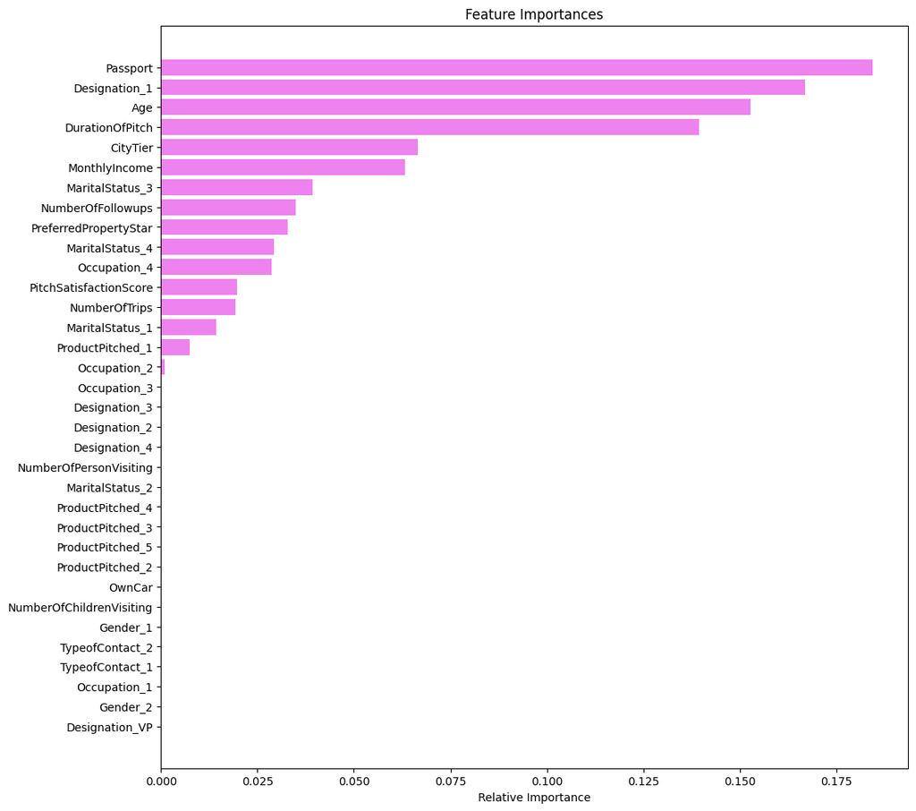

```python
feature_names = X_train.columns
importances = dtree_tuned.feature_importances_
indices = np.argsort(importances)

plt.figure(figsize=(12,12))
plt.title('Feature Importances')
plt.barh(range(len(indices)), importances[indices], color='violet', align='center')
plt.yticks(range(len(indices)), [feature_names[i] for i in indices])
plt.xlabel('Relative Importance')
plt.show()
```

- `Passport` is the most important feature.
- `Destination1`, `Age`, and `DurationOfPitch` are the other important features.

### Random Forest Model

```python
rf_estimator=RandomForestRegressor(random_state=1)
rf_estimator.fit(X_train,y_train)
```

```
RandomForestRegressor(random_state=1)
```

```python
rf_estimator_model_train_perf = model_performance_regression(rf_estimator, X_train,y_train)
print("Training performance \n",rf_estimator_model_train_perf)
```

```
Training performance
        RMSE       MAE  R-squared  Adj. R-squared  MAPE
0  0.092536  0.056012   0.945054        0.944399   inf
```

```python
rf_estimator_model_test_perf = model_performance_regression(rf_estimator, X_test,y_test)
print("Testing performance \n",rf_estimator_model_test_perf)
```

```
Testing performance
        RMSE       MAE  R-squared  Adj. R-squared  MAPE
0  0.257126  0.159282   0.575345        0.563353   inf
```

### Hyperparameter Tuning

```python
# Choose the type of classifier.
rf_tuned = RandomForestRegressor(random_state=1)

# Grid of parameters to choose from
parameters = {
                'max_depth':[4, 6, 8, 10, None],
                'max_features': ['sqrt','log2',None],
                'n_estimators': [80, 90, 100, 110, 120]
}

# Type of scoring used to compare parameter combinations
scorer = metrics.make_scorer(metrics.r2_score)

# Run the grid search
grid_obj = GridSearchCV(rf_tuned, parameters, scoring=scorer,cv=5)
grid_obj = grid_obj.fit(X_train, y_train)

# Set the clf to the best combination of parameters
rf_tuned = grid_obj.best_estimator_

# Fit the best algorithm to the data.
rf_tuned.fit(X_train, y_train)
```

```
RandomForestRegressor(max_features=None, n_estimators=80, random_state=1)
```

```python
rf_tuned_model_train_perf = model_performance_regression(rf_tuned, X_train, y_train)
print("Training performance \n",rf_tuned_model_train_perf)
```

```
Training performance
        RMSE       MAE  R-squared  Adj. R-squared  MAPE
0  0.093367  0.055746   0.944062        0.943396   inf
```

```python
rf_tuned_model_test_perf = model_performance_regression(rf_tuned, X_test, y_test)
print("Testing performance \n",rf_tuned_model_test_perf)
```

```
Testing performance
        RMSE       MAE  R-squared  Adj. R-squared  MAPE
0  0.255566  0.157556   0.580482        0.568635   inf
```

- No significant change in the result. The result is almost the same before or after the hyperparameter tuning.

```python
# importance of features in the tree building ( The importance of a feature is computed as the
#(normalized) total reduction of the criterion brought by that feature. It is also known as the Gini importance )

print(pd.DataFrame(rf_tuned.feature_importances_, columns = ["Imp"], index = X_train.columns).sort_values(by = 'Imp', ascending = False))
```

```
                               Imp
Age                       0.137751
DurationOfPitch           0.122906
MonthlyIncome             0.119058
Passport                  0.075463
NumberOfTrips             0.054900
PitchSatisfactionScore    0.053438
NumberOfFollowups         0.046636
CityTier                  0.046216
Designation_1             0.043494
ProductPitched_1          0.035865
PreferredPropertyStar     0.033592
MaritalStatus_1           0.022139
MaritalStatus_2           0.022034
NumberOfChildrenVisiting  0.021107
NumberOfPersonVisiting    0.019791
Occupation_4              0.018489
MaritalStatus_4           0.014808
MaritalStatus_3           0.014571
Gender_2                  0.011393
Gender_1                  0.011372
Occupation_3              0.011237
TypeofContact_1           0.010706
OwnCar                    0.010442
Occupation_2              0.010142
TypeofContact_2           0.010040
Designation_2             0.005228
ProductPitched_3          0.004890
Designation_3             0.003977
ProductPitched_2          0.003736
ProductPitched_4          0.001597
Designation_4             0.001519
Designation_VP            0.000740
ProductPitched_5          0.000677
Occupation_1              0.000047
```

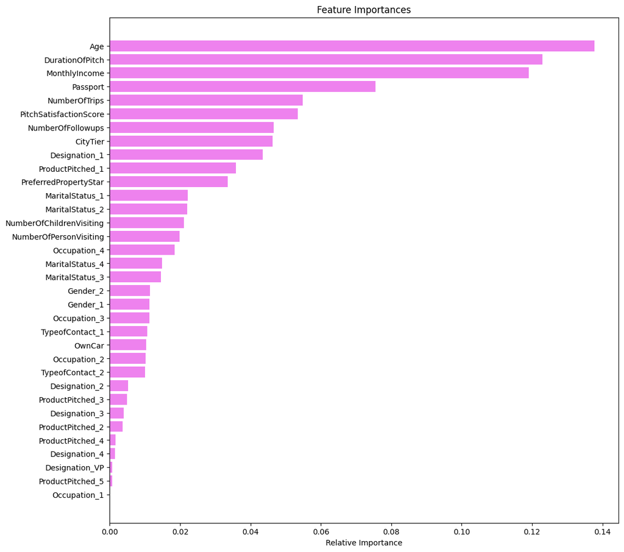

```python
feature_names = X_train.columns
importances = rf_tuned.feature_importances_
indices = np.argsort(importances)

plt.figure(figsize=(12,12))
plt.title('Feature Importances')
plt.barh(range(len(indices)), importances[indices], color='violet', align='center')
plt.yticks(range(len(indices)), [feature_names[i] for i in indices])
plt.xlabel('Relative Importance')
plt.show()
```

- `Age` is the most important feature for the tuned random forest model.
- The other important features for the tuned random forest model are `DurationOfPitch`, `MonthlyIncome`, and `Passport`.

## Boosting - Model Building and Hyperparameter Tuning

### AdaBoost Regressor

```python
ab_regressor=AdaBoostRegressor(random_state=1)
ab_regressor.fit(X_train,y_train)
```

```
AdaBoostRegressor(random_state=1)
```

```python
ab_regressor_model_train_perf = model_performance_regression(ab_regressor, X_train,y_train)
print("Training performance \n",ab_regressor_model_train_perf)
```

```
Training performance
        RMSE       MAE  R-squared  Adj. R-squared  MAPE
0  0.353488  0.246475   0.198196        0.188644   inf
```

```python
ab_regressor_model_test_perf = model_performance_regression(ab_regressor, X_test,y_test)
print("Testing performance \n",ab_regressor_model_test_perf)
```

```
Testing performance
        RMSE       MAE  R-squared  Adj. R-squared  MAPE
0  0.367089  0.257965   0.134459        0.110017   inf
```

- AdaBoost is generalizing well but it is giving poor performance, in terms of r2 score as well as RMSE, as compared to the decision tree and random forest models.

### Hyperparameter Tuning

```python
# Choose the type of classifier.
ab_tuned = AdaBoostRegressor(random_state=1)

# Grid of parameters to choose from
parameters = {'n_estimators': np.arange(10,100,10),
              'learning_rate': [1, 0.1, 0.5, 0.01],
              }

# Type of scoring used to compare parameter combinations
scorer = metrics.make_scorer(metrics.r2_score)

# Run the grid search
grid_obj = GridSearchCV(ab_tuned, parameters, scoring=scorer,cv=5)
grid_obj = grid_obj.fit(X_train, y_train)

# Set the clf to the best combination of parameters
ab_tuned = grid_obj.best_estimator_

# Fit the best algorithm to the data.
ab_tuned.fit(X_train, y_train)
```

```
AdaBoostRegressor(learning_rate=0.01, n_estimators=90, random_state=1)
```

```python
ab_tuned_model_train_perf = model_performance_regression(ab_tuned, X_train,y_train)
print("Training performance \n",ab_tuned_model_train_perf)
```

```
Training performance
       RMSE       MAE  R-squared  Adj. R-squared  MAPE
0  0.34412  0.254583   0.240134        0.231081   inf
```

```python
ab_tuned_model_test_perf = model_performance_regression(ab_tuned, X_test,y_test)
print("Testing performance \n",ab_tuned_model_test_perf)
```

```
Testing performance
        RMSE      MAE  R-squared  Adj. R-squared  MAPE
0  0.359432  0.26673    0.17019        0.146757   inf
```

- There is no significant improvement in the model after hyperparameter tuning.

```python
# importance of features in the tree building

print(pd.DataFrame(ab_tuned.feature_importances_, columns = ["Imp"], index = X_train.columns).sort_values(by = 'Imp', ascending = False))
```

```
                               Imp
Passport                  0.333395
Age                       0.134443
Designation_1             0.126723
ProductPitched_1          0.117633
CityTier                  0.069420
DurationOfPitch           0.040145
MaritalStatus_1           0.030797
MonthlyIncome             0.030299
NumberOfFollowups         0.025640
Occupation_4              0.020631
PreferredPropertyStar     0.019707
PitchSatisfactionScore    0.017093
MaritalStatus_4           0.016185
MaritalStatus_2           0.007039
NumberOfTrips             0.003693
ProductPitched_2          0.002091
MaritalStatus_3           0.001583
TypeofContact_1           0.000940
TypeofContact_2           0.000855
Occupation_3              0.000578
Gender_1                  0.000430
Occupation_2              0.000365
NumberOfChildrenVisiting  0.000315
Gender_2                  0.000000
ProductPitched_5          0.000000
ProductPitched_3          0.000000
ProductPitched_4          0.000000
Occupation_1              0.000000
OwnCar                    0.000000
Designation_4             0.000000
NumberOfPersonVisiting    0.000000
Designation_2             0.000000
Designation_3             0.000000
Designation_VP            0.000000
```

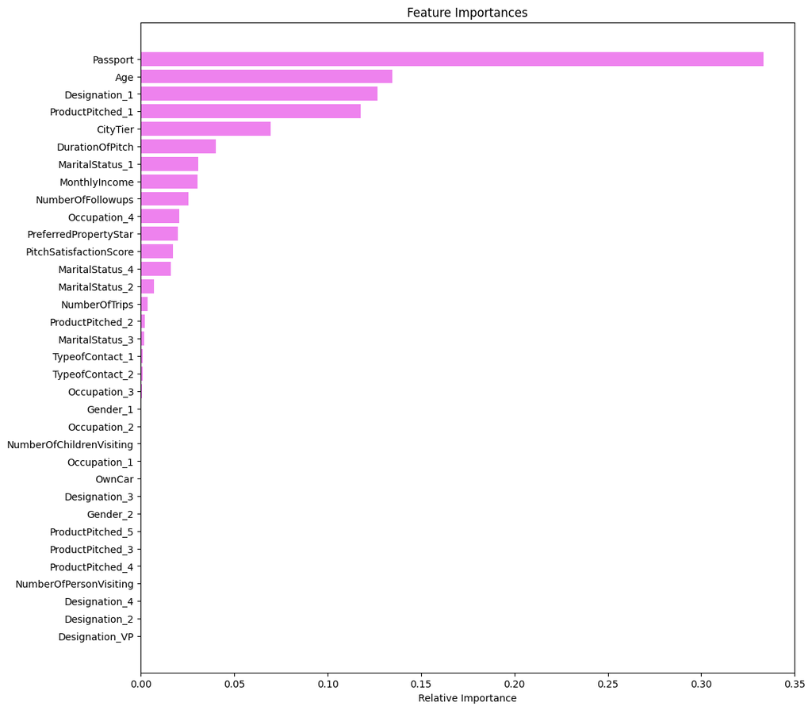

```python
feature_names = X_train.columns
importances = ab_tuned.feature_importances_
indices = np.argsort(importances)

plt.figure(figsize=(12,12))
plt.title('Feature Importances')
plt.barh(range(len(indices)), importances[indices], color='violet', align='center')
plt.yticks(range(len(indices)), [feature_names[i] for i in indices])
plt.xlabel('Relative Importance')
plt.show()
```

- `Passport` is the most important feature for the tuned adaboost model.
- The other important features for the tuned adaboost model are `Age`, `Destination_1`, and `ProductPitched_1`.

### Gradient Boosting Regressor

```python
gb_estimator=GradientBoostingRegressor(random_state=1)
gb_estimator.fit(X_train,y_train)
```

```
GradientBoostingRegressor(random_state=1)
```

```python
gb_estimator_model_train_perf = model_performance_regression(gb_estimator, X_train,y_train)
print("Training performance \n",gb_estimator_model_train_perf)
```

```
Training performance
        RMSE       MAE  R-squared  Adj. R-squared  MAPE
0  0.283562  0.192685   0.484041        0.477894   inf
```

```python
gb_estimator_model_test_perf = model_performance_regression(gb_estimator, X_test, y_test)
print("Testing performance \n",gb_estimator_model_test_perf)
```

```
Testing performance
        RMSE       MAE  R-squared  Adj. R-squared  MAPE
0  0.332333  0.229236     0.2906        0.270567   inf
```

- Gradient boosting is generalizing well but not as good as random forest.

### Hyperparameter Tuning

```python
# Choose the type of classifier.
gb_tuned = GradientBoostingRegressor(random_state=1)

# Grid of parameters to choose from
parameters = {'n_estimators': np.arange(50,200,25),
              'subsample':[0.7,0.8,0.9,1],
              'max_features':[0.7,0.8,0.9,1],
              'max_depth':[3,5,7,10]
              }

# Type of scoring used to compare parameter combinations
scorer = metrics.make_scorer(metrics.r2_score)

# Run the grid search
grid_obj = GridSearchCV(gb_tuned, parameters, scoring=scorer,cv=5)
grid_obj = grid_obj.fit(X_train, y_train)

# Set the clf to the best combination of parameters
gb_tuned = grid_obj.best_estimator_

# Fit the best algorithm to the data.
gb_tuned.fit(X_train, y_train)
```

```
GradientBoostingRegressor(max_depth=10, max_features=0.8, n_estimators=175,
                          random_state=1, subsample=0.8)
```

```python
gb_tuned_model_train_perf = model_performance_regression(gb_tuned, X_train,y_train)
print("Training performance \n",gb_tuned_model_train_perf)
```

```
Training performance
        RMSE       MAE  R-squared  Adj. R-squared  MAPE
0  0.001983  0.001459   0.999975        0.999974   inf
```

```python
gb_tuned_model_test_perf = model_performance_regression(gb_tuned, X_test, y_test)
print("Testing performance \n",gb_tuned_model_test_perf)
```

```
Testing performance
        RMSE       MAE  R-squared  Adj. R-squared  MAPE
0  0.240311  0.126944   0.629071        0.618596   inf
```

- We can see that the model has improved significantly in terms of r2 score.
- The r2 score has increased by approx 33% on the test data.
- RMSE has decreased by approx 9% for the test data.

```python
# importance of features in the tree building ( The importance of a feature is computed as the
#(normalized) total reduction of the criterion brought by that feature. It is also known as the Gini importance )

print(pd.DataFrame(gb_tuned.feature_importances_, columns = ["Imp"], index = X_train.columns).sort_values(by = 'Imp', ascending = False))
```

```
                                   Imp
Age                       1.498819e-01
MonthlyIncome             1.282199e-01
DurationOfPitch           1.240514e-01
Passport                  7.409558e-02
PitchSatisfactionScore    6.221527e-02
NumberOfTrips             5.339968e-02
NumberOfFollowups         4.416275e-02
CityTier                  4.210964e-02
PreferredPropertyStar     3.744285e-02
Designation_1             3.525087e-02
ProductPitched_1          3.151022e-02
MaritalStatus_1           2.428901e-02
NumberOfChildrenVisiting  1.912370e-02
MaritalStatus_4           1.797985e-02
MaritalStatus_2           1.647531e-02
NumberOfPersonVisiting    1.596982e-02
Occupation_4              1.465401e-02
MaritalStatus_3           1.352150e-02
TypeofContact_1           1.319195e-02
Occupation_3              1.243161e-02
Gender_2                  1.121228e-02
Gender_1                  1.099071e-02
TypeofContact_2           1.017053e-02
Occupation_2              9.950081e-03
OwnCar                    9.850634e-03
Designation_3             4.483709e-03
Designation_2             3.270573e-03
ProductPitched_2          3.196941e-03
ProductPitched_3          2.893080e-03
Designation_4             1.732648e-03
ProductPitched_4          1.070210e-03
ProductPitched_5          6.783763e-04
Designation_VP            5.233885e-04
Occupation_1              5.117049e-08
```

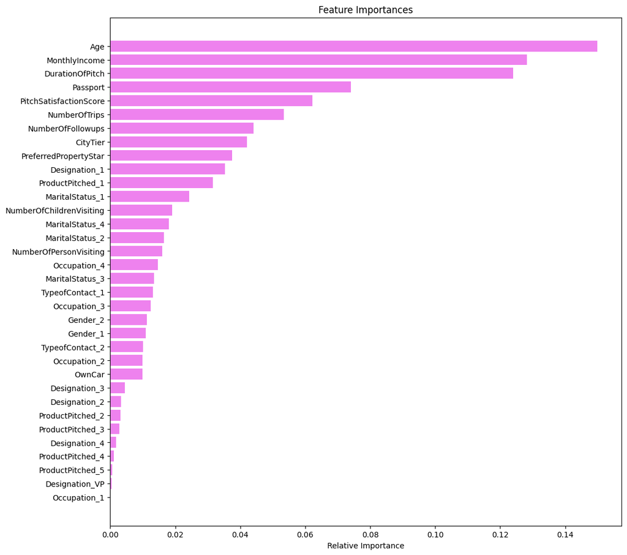

```python
feature_names = X_train.columns
importances = gb_tuned.feature_importances_
indices = np.argsort(importances)

plt.figure(figsize=(12,12))
plt.title('Feature Importances')
plt.barh(range(len(indices)), importances[indices], color='violet', align='center')
plt.yticks(range(len(indices)), [feature_names[i] for i in indices])
plt.xlabel('Relative Importance')
plt.show()
```

- `Age` is the most important feature in the tuned gradient boosting model.
- The other important features in the tuned gradient boosting model are `MonthlyIncome`, `DurationOfPitch`, and `Passport`.

## Stacking Model

**Now, let's build a stacking model with the tuned models - decision tree, random forest, and gradient boosting, then use XGBoost to get the final prediction.**

```python
estimators=[('Decision Tree', dtree_tuned),('Random Forest', rf_tuned),
           ('Gradient Boosting', gb_tuned)]
final_estimator=XGBRegressor(random_state=1)
```

```python
stacking_estimator=StackingRegressor(estimators=estimators, final_estimator=final_estimator,cv=5)
stacking_estimator.fit(X_train,y_train)
```

```
StackingRegressor(cv=5,
                  estimators=[('Decision Tree',
                               DecisionTreeRegressor(max_depth=6,
                                                     min_samples_leaf=3,
                                                     random_state=1)),
                              ('Random Forest',
                               RandomForestRegressor(max_features=None,
                                                     n_estimators=80,
                                                     random_state=1)),
                              ('Gradient Boosting',
                               GradientBoostingRegressor(max_depth=10,
                                                         max_features=0.8,
                                                         n_estimators=175,
                                                         random_state=1,
                                                         subsample=0.8))],
                  final_estimator...
                                               gpu_id=None, grow_policy=None,
                                               importance_type=None,
                                               interaction_constraints=None,
                                               learning_rate=None, max_bin=None,
                                               max_cat_threshold=None,
                                               max_cat_to_onehot=None,
                                               max_delta_step=None,
                                               max_depth=None, max_leaves=None,
                                               min_child_weight=None,
                                               missing=nan,
                                               monotone_constraints=None,
                                               n_estimators=100, n_jobs=None,
                                               num_parallel_tree=None,
                                               predictor=None, random_state=1, ...))
```

```python
stacking_estimator_model_train_perf = model_performance_regression(stacking_estimator, X_train, y_train)
print("Training performance \n",stacking_estimator_model_train_perf)
```

```
Training performance
        RMSE    MAE  R-squared  Adj. R-squared  MAPE
0  0.033339  0.009   0.992868        0.992783   inf
```

```python
stacking_estimator_model_test_perf = model_performance_regression(stacking_estimator, X_test, y_test)
print("Testing performance \n",stacking_estimator_model_test_perf)
```

```
Testing performance
        RMSE       MAE  R-squared  Adj. R-squared  MAPE
0  0.268876  0.112872   0.535647        0.522534   inf
```

## Comparing all models

```python
# training performance comparison

models_train_comp_df = pd.concat(
    [dtree_model_train_perf.T, dtree_tuned_model_train_perf.T, rf_estimator_model_train_perf.T,rf_tuned_model_train_perf.T,
    ab_regressor_model_train_perf.T,ab_tuned_model_train_perf.T,gb_estimator_model_train_perf.T,gb_tuned_model_train_perf.T,
    stacking_estimator_model_train_perf.T],
    axis=1,
)

models_train_comp_df.columns = [
    "Decision Tree",
    "Decision Tree Tuned",
    "Random Forest Estimator",
    "Random Forest Tuned",
    "Adaboost Regressor",
    "Adaboost Tuned",
    "Gradient Boost Estimator",
    "Gradient Boost Tuned",
    "Stacking Classifier"
]

print("Training performance comparison:")
models_train_comp_df
```

```
Training performance comparison:
```

|  | Decision Tree | Decision Tree Tuned | Random Forest Estimator | Random Forest Tuned | Adaboost Regressor | Adaboost Tuned | Gradient Boost Estimator | Gradient Boost Tuned | Stacking Classifier |
| --- | --- | --- | --- | --- | --- | --- | --- | --- | --- |
| RMSE | 0.0 | 0.303762 | 0.092536 | 0.093367 | 0.353488 | 0.344120 | 0.283562 | 0.001983 | 0.033339 |
| MAE | 0.0 | 0.184543 | 0.056012 | 0.055746 | 0.246475 | 0.254583 | 0.192685 | 0.001459 | 0.009000 |
| R-squared | 1.0 | 0.407912 | 0.945054 | 0.944062 | 0.198196 | 0.240134 | 0.484041 | 0.999975 | 0.992868 |
| Adj. R-squared | 1.0 | 0.400859 | 0.944399 | 0.943396 | 0.188644 | 0.231081 | 0.477894 | 0.999974 | 0.992783 |
| MAPE | 0.0 | inf | inf | inf | inf | inf | inf | inf | inf |

```python
# Testing performance comparison

models_test_comp_df = pd.concat(
    [dtree_model_test_perf.T, dtree_tuned_model_test_perf.T, rf_estimator_model_test_perf.T,rf_tuned_model_test_perf.T,
    ab_regressor_model_test_perf.T,ab_tuned_model_test_perf.T,gb_estimator_model_test_perf.T,gb_tuned_model_test_perf.T,
    stacking_estimator_model_test_perf.T],
    axis=1,
)

models_test_comp_df.columns = [
    "Decision Tree",
    "Decision Tree Tuned",
    "Random Forest Estimator",
    "Random Forest Tuned",
    "Adaboost Regressor",
    "Adaboost Tuned",
    "Gradient Boost Estimator",
    "Gradient Boost Tuned",
    "Stacking Classifier"
]

print("Testing performance comparison:")
models_test_comp_df
```

```
Testing performance comparison:
```

|  | Decision Tree | Decision Tree Tuned | Random Forest Estimator | Random Forest Tuned | Adaboost Regressor | Adaboost Tuned | Gradient Boost Estimator | Gradient Boost Tuned | Stacking Classifier |
| --- | --- | --- | --- | --- | --- | --- | --- | --- | --- |
| RMSE | 0.337345 | 0.356887 | 0.257126 | 0.255566 | 0.367089 | 0.359432 | 0.332333 | 0.240311 | 0.268876 |
| MAE | 0.113801 | 0.221798 | 0.159282 | 0.157556 | 0.257965 | 0.266730 | 0.229236 | 0.126944 | 0.112872 |
| R-squared | 0.269042 | 0.181902 | 0.575345 | 0.580482 | 0.134459 | 0.170190 | 0.290600 | 0.629071 | 0.535647 |
| Adj. R-squared | 0.248400 | 0.158800 | 0.563353 | 0.568635 | 0.110017 | 0.146757 | 0.270567 | 0.618596 | 0.522534 |
| MAPE | inf | inf | inf | inf | inf | inf | inf | inf | inf |

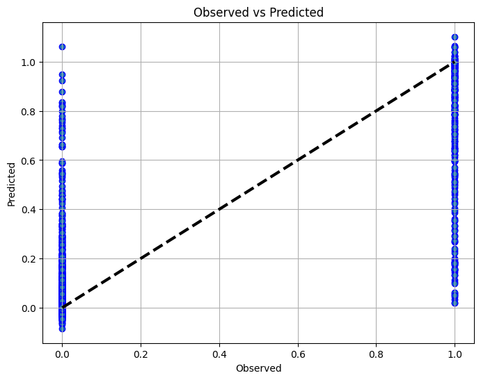

```python
# So plot observed and predicted values of the test data for the best model i.e. tuned gradient boosting model
fig, ax = plt.subplots(figsize=(8, 6))
y_pred=gb_tuned.predict(X_test)
ax.scatter(y_test, y_pred, edgecolors=(0, 0, 1))
ax.plot([y_test.min(), y_test.max()], [y_test.min(), y_test.max()], 'k--', lw=3)
ax.set_xlabel('Observed')
ax.set_ylabel('Predicted')
ax.set_title("Observed vs Predicted")
plt.grid()
plt.show()
```

- The points are not dense on the line where predicted is equal to the observed.
- This implies that most of the predicted values are not close to the true values with some exceptions as seen in the plot.

# Conclusions and Business Recommendations